# Risk Factor Analysis

## Outcome Variable

**Outcome Variable:** ever_swasted

## Predictor Variables

**Intervention Variable:** meducyrs

**Adjustment Set:**

- arm
- W_mage
- feducyrs
- hhwealth_quart
- W_mhtcm
- W_mwtkg
- W_mbmi
- W_gagebrth
- W_birthwt
- W_birthlen
- single
- impsan
- delta_W_mage
- delta_feducyrs
- delta_hhwealth_quart
- delta_W_mhtcm
- delta_W_mwtkg
- delta_W_mbmi
- delta_W_gagebrth
- delta_W_birthwt
- delta_W_birthlen
- delta_single
- delta_impsan

## Stratifying Variables

The analysis was stratified on these variable(s):

- agecat
- studyid
- country

## Data Summary

| agecat | studyid | country | meducyrs | ever_swasted | n_cell | n |
| --- | --- | --- | --- | --- | --- | --- |
| 0-24 months | ki0047075b-MAL-ED | BANGLADESH | High | 0 | 74 | 213 |
| 0-24 months | ki0047075b-MAL-ED | BANGLADESH | High | 1 | 4 | 213 |
| 0-24 months | ki0047075b-MAL-ED | BANGLADESH | Low | 0 | 63 | 213 |
| 0-24 months | ki0047075b-MAL-ED | BANGLADESH | Low | 1 | 7 | 213 |
| 0-24 months | ki0047075b-MAL-ED | BANGLADESH | Medium | 0 | 61 | 213 |
| 0-24 months | ki0047075b-MAL-ED | BANGLADESH | Medium | 1 | 4 | 213 |
| 0-24 months | ki0047075b-MAL-ED | BRAZIL | High | 0 | 77 | 232 |
| 0-24 months | ki0047075b-MAL-ED | BRAZIL | High | 1 | 2 | 232 |
| 0-24 months | ki0047075b-MAL-ED | BRAZIL | Low | 0 | 62 | 232 |
| 0-24 months | ki0047075b-MAL-ED | BRAZIL | Low | 1 | 1 | 232 |
| 0-24 months | ki0047075b-MAL-ED | BRAZIL | Medium | 0 | 89 | 232 |
| 0-24 months | ki0047075b-MAL-ED | BRAZIL | Medium | 1 | 1 | 232 |
| 0-24 months | ki0047075b-MAL-ED | INDIA | High | 0 | 57 | 220 |
| 0-24 months | ki0047075b-MAL-ED | INDIA | High | 1 | 6 | 220 |
| 0-24 months | ki0047075b-MAL-ED | INDIA | Low | 0 | 68 | 220 |
| 0-24 months | ki0047075b-MAL-ED | INDIA | Low | 1 | 8 | 220 |
| 0-24 months | ki0047075b-MAL-ED | INDIA | Medium | 0 | 73 | 220 |
| 0-24 months | ki0047075b-MAL-ED | INDIA | Medium | 1 | 8 | 220 |
| 0-24 months | ki0047075b-MAL-ED | NEPAL | High | 0 | 52 | 225 |
| 0-24 months | ki0047075b-MAL-ED | NEPAL | High | 1 | 1 | 225 |
| 0-24 months | ki0047075b-MAL-ED | NEPAL | Low | 0 | 93 | 225 |
| 0-24 months | ki0047075b-MAL-ED | NEPAL | Low | 1 | 3 | 225 |
| 0-24 months | ki0047075b-MAL-ED | NEPAL | Medium | 0 | 73 | 225 |
| 0-24 months | ki0047075b-MAL-ED | NEPAL | Medium | 1 | 3 | 225 |
| 0-24 months | ki0047075b-MAL-ED | PERU | High | 0 | 90 | 301 |
| 0-24 months | ki0047075b-MAL-ED | PERU | High | 1 | 0 | 301 |
| 0-24 months | ki0047075b-MAL-ED | PERU | Low | 0 | 101 | 301 |
| 0-24 months | ki0047075b-MAL-ED | PERU | Low | 1 | 3 | 301 |
| 0-24 months | ki0047075b-MAL-ED | PERU | Medium | 0 | 106 | 301 |
| 0-24 months | ki0047075b-MAL-ED | PERU | Medium | 1 | 1 | 301 |

[output cut: 438 more lines]

The following strata were considered:

- agecat: 0-24 months, studyid: ki0047075b-MAL-ED, country: BANGLADESH
- agecat: 0-24 months, studyid: ki0047075b-MAL-ED, country: BRAZIL
- agecat: 0-24 months, studyid: ki0047075b-MAL-ED, country: INDIA
- agecat: 0-24 months, studyid: ki0047075b-MAL-ED, country: NEPAL
- agecat: 0-24 months, studyid: ki0047075b-MAL-ED, country: PERU
- agecat: 0-24 months, studyid: ki0047075b-MAL-ED, country: SOUTH AFRICA
- agecat: 0-24 months, studyid: ki0047075b-MAL-ED, country: TANZANIA, UNITED REPUBLIC OF
- agecat: 0-24 months, studyid: ki1000108-CMC-V-BCS-2002, country: INDIA
- agecat: 0-24 months, studyid: ki1000108-IRC, country: INDIA
- agecat: 0-24 months, studyid: ki1000109-EE, country: PAKISTAN
- agecat: 0-24 months, studyid: ki1000304b-SAS-CompFeed, country: INDIA
- agecat: 0-24 months, studyid: ki1000304b-SAS-FoodSuppl, country: INDIA
- agecat: 0-24 months, studyid: ki1017093-NIH-Birth, country: BANGLADESH
- agecat: 0-24 months, studyid: ki1017093b-PROVIDE, country: BANGLADESH
- agecat: 0-24 months, studyid: ki1017093c-NIH-Crypto, country: BANGLADESH
- agecat: 0-24 months, studyid: ki1066203-TanzaniaChild2, country: TANZANIA, UNITED REPUBLIC OF
- agecat: 0-24 months, studyid: ki1112895-Guatemala BSC, country: GUATEMALA
- agecat: 0-24 months, studyid: ki1113344-GMS-Nepal, country: NEPAL
- agecat: 0-24 months, studyid: ki1119695-PROBIT, country: BELARUS
- agecat: 0-24 months, studyid: ki1126311-ZVITAMBO, country: ZIMBABWE
- agecat: 0-24 months, studyid: ki1135781-COHORTS, country: GUATEMALA
- agecat: 0-24 months, studyid: ki1135781-COHORTS, country: INDIA
- agecat: 0-24 months, studyid: ki1135781-COHORTS, country: PHILIPPINES
- agecat: 0-24 months, studyid: ki1148112-LCNI-5, country: MALAWI
- agecat: 0-24 months, studyid: kiGH5241-JiVitA-3, country: BANGLADESH
- agecat: 0-24 months, studyid: kiGH5241-JiVitA-4, country: BANGLADESH
- agecat: 0-6 months, studyid: ki0047075b-MAL-ED, country: BANGLADESH
- agecat: 0-6 months, studyid: ki0047075b-MAL-ED, country: BRAZIL
- agecat: 0-6 months, studyid: ki0047075b-MAL-ED, country: INDIA
- agecat: 0-6 months, studyid: ki0047075b-MAL-ED, country: NEPAL
- agecat: 0-6 months, studyid: ki0047075b-MAL-ED, country: PERU
- agecat: 0-6 months, studyid: ki0047075b-MAL-ED, country: SOUTH AFRICA
- agecat: 0-6 months, studyid: ki0047075b-MAL-ED, country: TANZANIA, UNITED REPUBLIC OF
- agecat: 0-6 months, studyid: ki1000108-CMC-V-BCS-2002, country: INDIA
- agecat: 0-6 months, studyid: ki1000108-IRC, country: INDIA
- agecat: 0-6 months, studyid: ki1000109-EE, country: PAKISTAN
- agecat: 0-6 months, studyid: ki1000304b-SAS-CompFeed, country: INDIA
- agecat: 0-6 months, studyid: ki1000304b-SAS-FoodSuppl, country: INDIA
- agecat: 0-6 months, studyid: ki1017093-NIH-Birth, country: BANGLADESH
- agecat: 0-6 months, studyid: ki1017093b-PROVIDE, country: BANGLADESH
- agecat: 0-6 months, studyid: ki1017093c-NIH-Crypto, country: BANGLADESH
- agecat: 0-6 months, studyid: ki1066203-TanzaniaChild2, country: TANZANIA, UNITED REPUBLIC OF
- agecat: 0-6 months, studyid: ki1112895-Guatemala BSC, country: GUATEMALA
- agecat: 0-6 months, studyid: ki1113344-GMS-Nepal, country: NEPAL
- agecat: 0-6 months, studyid: ki1119695-PROBIT, country: BELARUS
- agecat: 0-6 months, studyid: ki1126311-ZVITAMBO, country: ZIMBABWE
- agecat: 0-6 months, studyid: ki1135781-COHORTS, country: GUATEMALA
- agecat: 0-6 months, studyid: ki1135781-COHORTS, country: INDIA
- agecat: 0-6 months, studyid: ki1135781-COHORTS, country: PHILIPPINES
- agecat: 0-6 months, studyid: ki1148112-LCNI-5, country: MALAWI
- agecat: 0-6 months, studyid: kiGH5241-JiVitA-3, country: BANGLADESH
- agecat: 0-6 months, studyid: kiGH5241-JiVitA-4, country: BANGLADESH
- agecat: 6-24 months, studyid: ki0047075b-MAL-ED, country: BANGLADESH
- agecat: 6-24 months, studyid: ki0047075b-MAL-ED, country: BRAZIL
- agecat: 6-24 months, studyid: ki0047075b-MAL-ED, country: INDIA
- agecat: 6-24 months, studyid: ki0047075b-MAL-ED, country: NEPAL
- agecat: 6-24 months, studyid: ki0047075b-MAL-ED, country: PERU
- agecat: 6-24 months, studyid: ki0047075b-MAL-ED, country: SOUTH AFRICA
- agecat: 6-24 months, studyid: ki0047075b-MAL-ED, country: TANZANIA, UNITED REPUBLIC OF
- agecat: 6-24 months, studyid: ki1000108-CMC-V-BCS-2002, country: INDIA
- agecat: 6-24 months, studyid: ki1000108-IRC, country: INDIA
- agecat: 6-24 months, studyid: ki1000109-EE, country: PAKISTAN
- agecat: 6-24 months, studyid: ki1000304b-SAS-CompFeed, country: INDIA
- agecat: 6-24 months, studyid: ki1000304b-SAS-FoodSuppl, country: INDIA
- agecat: 6-24 months, studyid: ki1017093-NIH-Birth, country: BANGLADESH
- agecat: 6-24 months, studyid: ki1017093b-PROVIDE, country: BANGLADESH
- agecat: 6-24 months, studyid: ki1017093c-NIH-Crypto, country: BANGLADESH
- agecat: 6-24 months, studyid: ki1066203-TanzaniaChild2, country: TANZANIA, UNITED REPUBLIC OF
- agecat: 6-24 months, studyid: ki1112895-Guatemala BSC, country: GUATEMALA
- agecat: 6-24 months, studyid: ki1113344-GMS-Nepal, country: NEPAL
- agecat: 6-24 months, studyid: ki1119695-PROBIT, country: BELARUS
- agecat: 6-24 months, studyid: ki1126311-ZVITAMBO, country: ZIMBABWE
- agecat: 6-24 months, studyid: ki1135781-COHORTS, country: GUATEMALA
- agecat: 6-24 months, studyid: ki1135781-COHORTS, country: INDIA
- agecat: 6-24 months, studyid: ki1135781-COHORTS, country: PHILIPPINES
- agecat: 6-24 months, studyid: ki1148112-LCNI-5, country: MALAWI
- agecat: 6-24 months, studyid: kiGH5241-JiVitA-3, country: BANGLADESH
- agecat: 6-24 months, studyid: kiGH5241-JiVitA-4, country: BANGLADESH

### Dropped Strata

Some strata were dropped due to rare outcomes:

- agecat: 0-24 months, studyid: ki0047075b-MAL-ED, country: BANGLADESH
- agecat: 0-24 months, studyid: ki0047075b-MAL-ED, country: BRAZIL
- agecat: 0-24 months, studyid: ki0047075b-MAL-ED, country: NEPAL
- agecat: 0-24 months, studyid: ki0047075b-MAL-ED, country: PERU
- agecat: 0-24 months, studyid: ki0047075b-MAL-ED, country: SOUTH AFRICA
- agecat: 0-24 months, studyid: ki0047075b-MAL-ED, country: TANZANIA, UNITED REPUBLIC OF
- agecat: 0-24 months, studyid: ki1000109-EE, country: PAKISTAN
- agecat: 0-24 months, studyid: ki1000304b-SAS-FoodSuppl, country: INDIA
- agecat: 0-24 months, studyid: ki1112895-Guatemala BSC, country: GUATEMALA
- agecat: 0-24 months, studyid: ki1148112-LCNI-5, country: MALAWI
- agecat: 0-6 months, studyid: ki0047075b-MAL-ED, country: BANGLADESH
- agecat: 0-6 months, studyid: ki0047075b-MAL-ED, country: BRAZIL
- agecat: 0-6 months, studyid: ki0047075b-MAL-ED, country: INDIA
- agecat: 0-6 months, studyid: ki0047075b-MAL-ED, country: NEPAL
- agecat: 0-6 months, studyid: ki0047075b-MAL-ED, country: PERU
- agecat: 0-6 months, studyid: ki0047075b-MAL-ED, country: SOUTH AFRICA
- agecat: 0-6 months, studyid: ki0047075b-MAL-ED, country: TANZANIA, UNITED REPUBLIC OF
- agecat: 0-6 months, studyid: ki1000109-EE, country: PAKISTAN
- agecat: 0-6 months, studyid: ki1000304b-SAS-FoodSuppl, country: INDIA
- agecat: 0-6 months, studyid: ki1066203-TanzaniaChild2, country: TANZANIA, UNITED REPUBLIC OF
- agecat: 0-6 months, studyid: ki1112895-Guatemala BSC, country: GUATEMALA
- agecat: 0-6 months, studyid: ki1148112-LCNI-5, country: MALAWI
- agecat: 6-24 months, studyid: ki0047075b-MAL-ED, country: BANGLADESH
- agecat: 6-24 months, studyid: ki0047075b-MAL-ED, country: BRAZIL
- agecat: 6-24 months, studyid: ki0047075b-MAL-ED, country: INDIA
- agecat: 6-24 months, studyid: ki0047075b-MAL-ED, country: NEPAL
- agecat: 6-24 months, studyid: ki0047075b-MAL-ED, country: PERU
- agecat: 6-24 months, studyid: ki0047075b-MAL-ED, country: SOUTH AFRICA
- agecat: 6-24 months, studyid: ki0047075b-MAL-ED, country: TANZANIA, UNITED REPUBLIC OF
- agecat: 6-24 months, studyid: ki1000109-EE, country: PAKISTAN
- agecat: 6-24 months, studyid: ki1000304b-SAS-FoodSuppl, country: INDIA
- agecat: 6-24 months, studyid: ki1017093b-PROVIDE, country: BANGLADESH
- agecat: 6-24 months, studyid: ki1017093c-NIH-Crypto, country: BANGLADESH
- agecat: 6-24 months, studyid: ki1112895-Guatemala BSC, country: GUATEMALA
- agecat: 6-24 months, studyid: ki1119695-PROBIT, country: BELARUS
- agecat: 6-24 months, studyid: ki1148112-LCNI-5, country: MALAWI

## Methods Detail

We’re interested in the causal parameters $E[Y_a]$ for all values of $a \in \mathcal{A}$. These parameters represent the mean outcome if, possibly contrary to fact, we intervened to set all units to have $A=a$. Under the randomization and positivity assumptions, these are identified by the statistical parameters $\psi_a=E_W[E_{Y|A,W}(Y|A=a,W)]$. In addition, we’re interested in the mean of $Y$, $E[Y]$ under no intervention (the observed mean). We will estimate these parameters by using SuperLearner to fit the relevant likelihood factors – $E_{Y|A,W}(Y|A=a,W)$ and $p(A=a|W)$, and then updating our likelihood fit using a joint TMLE.

For unadjusted analyses ($W=\{\}$), initial likelihoods were estimated using Lrnr_glm to estimate the simple $E(Y|A)$ and Lrnr_mean to estimate $p(A)$. For adjusted analyses, a small library containing Lrnr_glmnet, Lrnr_xgboost, and Lrnr_mean was used.

Having estimated these parameters, we will then use the delta method to estimate relative risks and attributable risks relative to a prespecified baseline level of $A$.

# Results Detail

## Results Plots

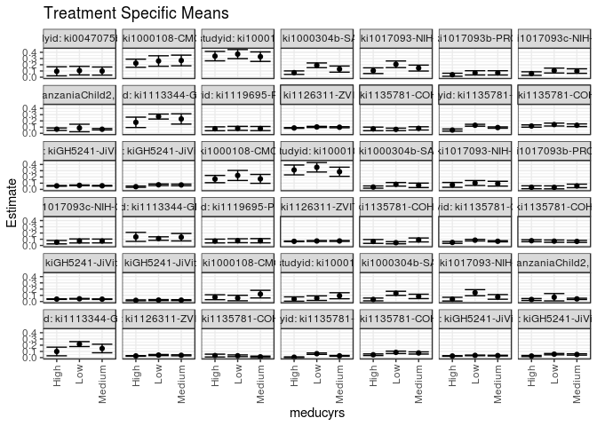

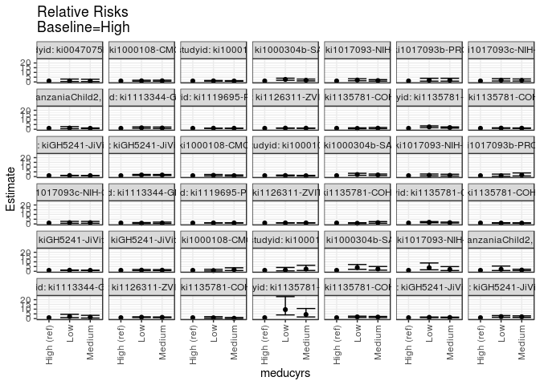

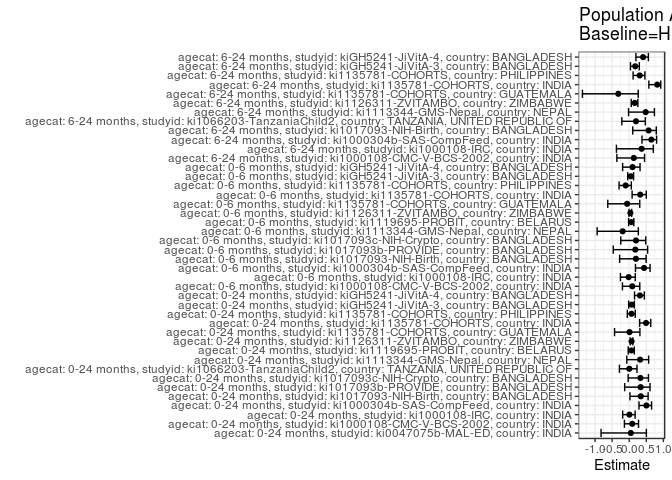

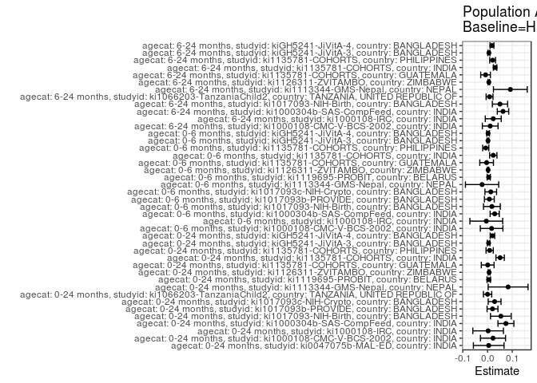

## Results Table

### Parameter: TSM

| agecat | studyid | country | intervention_level | baseline_level | estimate | ci_lower | ci_upper |
| --- | --- | --- | --- | --- | --- | --- | --- |
| 0-24 months | ki0047075b-MAL-ED | INDIA | High | NA | 0.0952381 | 0.0225874 | 0.1678888 |
| 0-24 months | ki0047075b-MAL-ED | INDIA | Low | NA | 0.1052632 | 0.0361093 | 0.1744170 |
| 0-24 months | ki0047075b-MAL-ED | INDIA | Medium | NA | 0.0987654 | 0.0336452 | 0.1638857 |
| 0-24 months | ki1000108-CMC-V-BCS-2002 | INDIA | High | NA | 0.2245889 | 0.1594185 | 0.2897594 |
| 0-24 months | ki1000108-CMC-V-BCS-2002 | INDIA | Low | NA | 0.2606137 | 0.1766360 | 0.3445914 |
| 0-24 months | ki1000108-CMC-V-BCS-2002 | INDIA | Medium | NA | 0.2687345 | 0.1830355 | 0.3544336 |
| 0-24 months | ki1000108-IRC | INDIA | High | NA | 0.3389887 | 0.2631640 | 0.4148134 |
| 0-24 months | ki1000108-IRC | INDIA | Low | NA | 0.3711669 | 0.2983447 | 0.4439891 |
| 0-24 months | ki1000108-IRC | INDIA | Medium | NA | 0.3301716 | 0.2537147 | 0.4066285 |
| 0-24 months | ki1000304b-SAS-CompFeed | INDIA | High | NA | 0.0731309 | 0.0448889 | 0.1013730 |
| 0-24 months | ki1000304b-SAS-CompFeed | INDIA | Low | NA | 0.1913036 | 0.1535992 | 0.2290081 |
| 0-24 months | ki1000304b-SAS-CompFeed | INDIA | Medium | NA | 0.1305096 | 0.0812667 | 0.1797525 |
| 0-24 months | ki1017093-NIH-Birth | BANGLADESH | High | NA | 0.1047862 | 0.0588371 | 0.1507354 |
| 0-24 months | ki1017093-NIH-Birth | BANGLADESH | Low | NA | 0.2077783 | 0.1545948 | 0.2609618 |
| 0-24 months | ki1017093-NIH-Birth | BANGLADESH | Medium | NA | 0.1468541 | 0.0995563 | 0.1941519 |
| 0-24 months | ki1017093b-PROVIDE | BANGLADESH | High | NA | 0.0399032 | 0.0155657 | 0.0642406 |
| 0-24 months | ki1017093b-PROVIDE | BANGLADESH | Low | NA | 0.0701504 | 0.0362095 | 0.1040914 |
| 0-24 months | ki1017093b-PROVIDE | BANGLADESH | Medium | NA | 0.0698077 | 0.0357035 | 0.1039118 |
| 0-24 months | ki1017093c-NIH-Crypto | BANGLADESH | High | NA | 0.0583892 | 0.0297427 | 0.0870357 |
| 0-24 months | ki1017093c-NIH-Crypto | BANGLADESH | Low | NA | 0.1068939 | 0.0679994 | 0.1457885 |
| 0-24 months | ki1017093c-NIH-Crypto | BANGLADESH | Medium | NA | 0.0988411 | 0.0627488 | 0.1349333 |
| 0-24 months | ki1066203-TanzaniaChild2 | TANZANIA, UNITED REPUBLIC OF | High | NA | 0.0660225 | 0.0464878 | 0.0855573 |
| 0-24 months | ki1066203-TanzaniaChild2 | TANZANIA, UNITED REPUBLIC OF | Low | NA | 0.0853659 | 0.0248738 | 0.1458579 |
| 0-24 months | ki1066203-TanzaniaChild2 | TANZANIA, UNITED REPUBLIC OF | Medium | NA | 0.0653595 | 0.0535488 | 0.0771701 |
| 0-24 months | ki1113344-GMS-Nepal | NEPAL | High | NA | 0.1760526 | 0.0926836 | 0.2594215 |
| 0-24 months | ki1113344-GMS-Nepal | NEPAL | Low | NA | 0.2692905 | 0.2290033 | 0.3095776 |
| 0-24 months | ki1113344-GMS-Nepal | NEPAL | Medium | NA | 0.2306342 | 0.1482413 | 0.3130272 |
| 0-24 months | ki1119695-PROBIT | BELARUS | High | NA | 0.0724885 | 0.0412176 | 0.1037593 |
| 0-24 months | ki1119695-PROBIT | BELARUS | Low | NA | 0.0793022 | 0.0473578 | 0.1112466 |
| 0-24 months | ki1119695-PROBIT | BELARUS | Medium | NA | 0.0765252 | 0.0432274 | 0.1098230 |

[output cut: 96 more lines]

### Parameter: E(Y)

| agecat | studyid | country | intervention_level | baseline_level | estimate | ci_lower | ci_upper |
| --- | --- | --- | --- | --- | --- | --- | --- |
| 0-24 months | ki0047075b-MAL-ED | INDIA | NA | NA | 0.1000000 | 0.0602674 | 0.1397326 |
| 0-24 months | ki1000108-CMC-V-BCS-2002 | INDIA | NA | NA | 0.2466488 | 0.2028447 | 0.2904529 |
| 0-24 months | ki1000108-IRC | INDIA | NA | NA | 0.3414634 | 0.2955068 | 0.3874201 |
| 0-24 months | ki1000304b-SAS-CompFeed | INDIA | NA | NA | 0.1473893 | 0.1184132 | 0.1763654 |
| 0-24 months | ki1017093-NIH-Birth | BANGLADESH | NA | NA | 0.1586538 | 0.1299648 | 0.1873429 |
| 0-24 months | ki1017093b-PROVIDE | BANGLADESH | NA | NA | 0.0600000 | 0.0423945 | 0.0776055 |
| 0-24 months | ki1017093c-NIH-Crypto | BANGLADESH | NA | NA | 0.0870712 | 0.0669870 | 0.1071555 |
| 0-24 months | ki1066203-TanzaniaChild2 | TANZANIA, UNITED REPUBLIC OF | NA | NA | 0.0662196 | 0.0562399 | 0.0761994 |
| 0-24 months | ki1113344-GMS-Nepal | NEPAL | NA | NA | 0.2591508 | 0.2262659 | 0.2920357 |
| 0-24 months | ki1119695-PROBIT | BELARUS | NA | NA | 0.0774648 | 0.0450418 | 0.1098878 |
| 0-24 months | ki1126311-ZVITAMBO | ZIMBABWE | NA | NA | 0.0922734 | 0.0874665 | 0.0970804 |
| 0-24 months | ki1135781-COHORTS | GUATEMALA | NA | NA | 0.0711044 | 0.0572455 | 0.0849633 |
| 0-24 months | ki1135781-COHORTS | INDIA | NA | NA | 0.1030116 | 0.0952175 | 0.1108057 |
| 0-24 months | ki1135781-COHORTS | PHILIPPINES | NA | NA | 0.1254516 | 0.1136848 | 0.1372183 |
| 0-24 months | kiGH5241-JiVitA-3 | BANGLADESH | NA | NA | 0.0610653 | 0.0575838 | 0.0645468 |
| 0-24 months | kiGH5241-JiVitA-4 | BANGLADESH | NA | NA | 0.0630996 | 0.0561390 | 0.0700602 |
| 0-6 months | ki1000108-CMC-V-BCS-2002 | INDIA | NA | NA | 0.1820652 | 0.1425842 | 0.2215462 |
| 0-6 months | ki1000108-IRC | INDIA | NA | NA | 0.3073171 | 0.2626027 | 0.3520314 |
| 0-6 months | ki1000304b-SAS-CompFeed | INDIA | NA | NA | 0.0664452 | 0.0425975 | 0.0902929 |
| 0-6 months | ki1017093-NIH-Birth | BANGLADESH | NA | NA | 0.0900322 | 0.0675202 | 0.1125442 |
| 0-6 months | ki1017093b-PROVIDE | BANGLADESH | NA | NA | 0.0414286 | 0.0266555 | 0.0562017 |
| 0-6 months | ki1017093c-NIH-Crypto | BANGLADESH | NA | NA | 0.0659631 | 0.0482810 | 0.0836451 |
| 0-6 months | ki1113344-GMS-Nepal | NEPAL | NA | NA | 0.1156662 | 0.0916631 | 0.1396693 |
| 0-6 months | ki1119695-PROBIT | BELARUS | NA | NA | 0.0760580 | 0.0435003 | 0.1086157 |
| 0-6 months | ki1126311-ZVITAMBO | ZIMBABWE | NA | NA | 0.0688209 | 0.0646022 | 0.0730397 |
| 0-6 months | ki1135781-COHORTS | GUATEMALA | NA | NA | 0.0608944 | 0.0464300 | 0.0753587 |
| 0-6 months | ki1135781-COHORTS | INDIA | NA | NA | 0.0718095 | 0.0650627 | 0.0785562 |
| 0-6 months | ki1135781-COHORTS | PHILIPPINES | NA | NA | 0.0693167 | 0.0602923 | 0.0783411 |
| 0-6 months | kiGH5241-JiVitA-3 | BANGLADESH | NA | NA | 0.0414166 | 0.0384340 | 0.0443992 |
| 0-6 months | kiGH5241-JiVitA-4 | BANGLADESH | NA | NA | 0.0218633 | 0.0173413 | 0.0263853 |
| 6-24 months | ki1000108-CMC-V-BCS-2002 | INDIA | NA | NA | 0.0804290 | 0.0527929 | 0.1080650 |
| 6-24 months | ki1000108-IRC | INDIA | NA | NA | 0.0634146 | 0.0397960 | 0.0870333 |
| 6-24 months | ki1000304b-SAS-CompFeed | INDIA | NA | NA | 0.0964723 | 0.0729872 | 0.1199573 |
| 6-24 months | ki1017093-NIH-Birth | BANGLADESH | NA | NA | 0.0885609 | 0.0646203 | 0.1125014 |
| 6-24 months | ki1066203-TanzaniaChild2 | TANZANIA, UNITED REPUBLIC OF | NA | NA | 0.0412730 | 0.0325768 | 0.0499692 |
| 6-24 months | ki1113344-GMS-Nepal | NEPAL | NA | NA | 0.1908007 | 0.1589868 | 0.2226146 |
| 6-24 months | ki1126311-ZVITAMBO | ZIMBABWE | NA | NA | 0.0329630 | 0.0295956 | 0.0363303 |
| 6-24 months | ki1135781-COHORTS | GUATEMALA | NA | NA | 0.0250417 | 0.0161900 | 0.0338934 |
| 6-24 months | ki1135781-COHORTS | INDIA | NA | NA | 0.0372331 | 0.0322193 | 0.0422468 |
| 6-24 months | ki1135781-COHORTS | PHILIPPINES | NA | NA | 0.0669277 | 0.0576848 | 0.0761707 |
| 6-24 months | kiGH5241-JiVitA-3 | BANGLADESH | NA | NA | 0.0319444 | 0.0290509 | 0.0348380 |
| 6-24 months | kiGH5241-JiVitA-4 | BANGLADESH | NA | NA | 0.0439439 | 0.0381166 | 0.0497712 |

### Parameter: RR

| agecat | studyid | country | intervention_level | baseline_level | estimate | ci_lower | ci_upper |
| --- | --- | --- | --- | --- | --- | --- | --- |
| 0-24 months | ki0047075b-MAL-ED | INDIA | High | High | 1.0000000 | 1.0000000 | 1.000000 |
| 0-24 months | ki0047075b-MAL-ED | INDIA | Low | High | 1.1052631 | 0.4038751 | 3.024713 |
| 0-24 months | ki0047075b-MAL-ED | INDIA | Medium | High | 1.0370370 | 0.3783556 | 2.842421 |
| 0-24 months | ki1000108-CMC-V-BCS-2002 | INDIA | High | High | 1.0000000 | 1.0000000 | 1.000000 |
| 0-24 months | ki1000108-CMC-V-BCS-2002 | INDIA | Low | High | 1.1604033 | 0.7518612 | 1.790937 |
| 0-24 months | ki1000108-CMC-V-BCS-2002 | INDIA | Medium | High | 1.1965619 | 0.7763895 | 1.844126 |
| 0-24 months | ki1000108-IRC | INDIA | High | High | 1.0000000 | 1.0000000 | 1.000000 |
| 0-24 months | ki1000108-IRC | INDIA | Low | High | 1.0949240 | 0.8237126 | 1.455433 |
| 0-24 months | ki1000108-IRC | INDIA | Medium | High | 0.9739900 | 0.7127188 | 1.331039 |
| 0-24 months | ki1000304b-SAS-CompFeed | INDIA | High | High | 1.0000000 | 1.0000000 | 1.000000 |
| 0-24 months | ki1000304b-SAS-CompFeed | INDIA | Low | High | 2.6159054 | 1.7417349 | 3.928819 |
| 0-24 months | ki1000304b-SAS-CompFeed | INDIA | Medium | High | 1.7846016 | 1.0623374 | 2.997920 |
| 0-24 months | ki1017093-NIH-Birth | BANGLADESH | High | High | 1.0000000 | 1.0000000 | 1.000000 |
| 0-24 months | ki1017093-NIH-Birth | BANGLADESH | Low | High | 1.9828784 | 1.1930103 | 3.295702 |
| 0-24 months | ki1017093-NIH-Birth | BANGLADESH | Medium | High | 1.4014640 | 0.8126833 | 2.416810 |
| 0-24 months | ki1017093b-PROVIDE | BANGLADESH | High | High | 1.0000000 | 1.0000000 | 1.000000 |
| 0-24 months | ki1017093b-PROVIDE | BANGLADESH | Low | High | 1.7580173 | 0.8065841 | 3.831745 |
| 0-24 months | ki1017093b-PROVIDE | BANGLADESH | Medium | High | 1.7494267 | 0.7999717 | 3.825753 |
| 0-24 months | ki1017093c-NIH-Crypto | BANGLADESH | High | High | 1.0000000 | 1.0000000 | 1.000000 |
| 0-24 months | ki1017093c-NIH-Crypto | BANGLADESH | Low | High | 1.8307139 | 0.9938070 | 3.372399 |
| 0-24 months | ki1017093c-NIH-Crypto | BANGLADESH | Medium | High | 1.6927969 | 0.9177465 | 3.122389 |
| 0-24 months | ki1066203-TanzaniaChild2 | TANZANIA, UNITED REPUBLIC OF | High | High | 1.0000000 | 1.0000000 | 1.000000 |
| 0-24 months | ki1066203-TanzaniaChild2 | TANZANIA, UNITED REPUBLIC OF | Low | High | 1.2929804 | 0.5999184 | 2.786709 |
| 0-24 months | ki1066203-TanzaniaChild2 | TANZANIA, UNITED REPUBLIC OF | Medium | High | 0.9899570 | 0.6999193 | 1.400183 |
| 0-24 months | ki1113344-GMS-Nepal | NEPAL | High | High | 1.0000000 | 1.0000000 | 1.000000 |
| 0-24 months | ki1113344-GMS-Nepal | NEPAL | Low | High | 1.5296026 | 0.9304148 | 2.514668 |
| 0-24 months | ki1113344-GMS-Nepal | NEPAL | Medium | High | 1.3100307 | 0.7241887 | 2.369797 |
| 0-24 months | ki1119695-PROBIT | BELARUS | High | High | 1.0000000 | 1.0000000 | 1.000000 |
| 0-24 months | ki1119695-PROBIT | BELARUS | Low | High | 1.0939971 | 0.9774162 | 1.224483 |
| 0-24 months | ki1119695-PROBIT | BELARUS | Medium | High | 1.0556881 | 0.9389019 | 1.187001 |

[output cut: 96 more lines]

### Parameter: PAR

| agecat | studyid | country | intervention_level | baseline_level | estimate | ci_lower | ci_upper |
| --- | --- | --- | --- | --- | --- | --- | --- |
| 0-24 months | ki0047075b-MAL-ED | INDIA | High | NA | 0.0047619 | -0.0571564 | 0.0666802 |
| 0-24 months | ki1000108-CMC-V-BCS-2002 | INDIA | High | NA | 0.0220599 | -0.0286023 | 0.0727220 |
| 0-24 months | ki1000108-IRC | INDIA | High | NA | 0.0024747 | -0.0593247 | 0.0642740 |
| 0-24 months | ki1000304b-SAS-CompFeed | INDIA | High | NA | 0.0742583 | 0.0420726 | 0.1064441 |
| 0-24 months | ki1017093-NIH-Birth | BANGLADESH | High | NA | 0.0538676 | 0.0120337 | 0.0957015 |
| 0-24 months | ki1017093b-PROVIDE | BANGLADESH | High | NA | 0.0200968 | -0.0018938 | 0.0420874 |
| 0-24 months | ki1017093c-NIH-Crypto | BANGLADESH | High | NA | 0.0286820 | 0.0028191 | 0.0545450 |
| 0-24 months | ki1066203-TanzaniaChild2 | TANZANIA, UNITED REPUBLIC OF | High | NA | 0.0001971 | -0.0166125 | 0.0170066 |
| 0-24 months | ki1113344-GMS-Nepal | NEPAL | High | NA | 0.0830983 | 0.0025849 | 0.1636116 |
| 0-24 months | ki1119695-PROBIT | BELARUS | High | NA | 0.0049763 | -0.0022350 | 0.0121877 |
| 0-24 months | ki1126311-ZVITAMBO | ZIMBABWE | High | NA | 0.0064166 | 0.0028552 | 0.0099780 |
| 0-24 months | ki1135781-COHORTS | GUATEMALA | High | NA | 0.0006753 | -0.0251409 | 0.0264916 |
| 0-24 months | ki1135781-COHORTS | INDIA | High | NA | 0.0508464 | 0.0339335 | 0.0677593 |
| 0-24 months | ki1135781-COHORTS | PHILIPPINES | High | NA | 0.0086411 | -0.0060285 | 0.0233107 |
| 0-24 months | kiGH5241-JiVitA-3 | BANGLADESH | High | NA | 0.0043824 | -0.0007476 | 0.0095123 |
| 0-24 months | kiGH5241-JiVitA-4 | BANGLADESH | High | NA | 0.0198136 | 0.0107267 | 0.0289005 |
| 0-6 months | ki1000108-CMC-V-BCS-2002 | INDIA | High | NA | 0.0164664 | -0.0292330 | 0.0621658 |
| 0-6 months | ki1000108-IRC | INDIA | High | NA | -0.0049849 | -0.0711654 | 0.0611955 |
| 0-6 months | ki1000304b-SAS-CompFeed | INDIA | High | NA | 0.0289671 | 0.0105758 | 0.0473584 |
| 0-6 months | ki1017093-NIH-Birth | BANGLADESH | High | NA | 0.0176466 | -0.0162605 | 0.0515536 |
| 0-6 months | ki1017093b-PROVIDE | BANGLADESH | High | NA | 0.0073860 | -0.0124915 | 0.0272636 |
| 0-6 months | ki1017093c-NIH-Crypto | BANGLADESH | High | NA | 0.0131283 | -0.0104381 | 0.0366946 |
| 0-6 months | ki1113344-GMS-Nepal | NEPAL | High | NA | -0.0221129 | -0.0892243 | 0.0449984 |
| 0-6 months | ki1119695-PROBIT | BELARUS | High | NA | 0.0047011 | -0.0016977 | 0.0111000 |
| 0-6 months | ki1126311-ZVITAMBO | ZIMBABWE | High | NA | 0.0023706 | -0.0002493 | 0.0049905 |
| 0-6 months | ki1135781-COHORTS | GUATEMALA | High | NA | -0.0037015 | -0.0313010 | 0.0238981 |
| 0-6 months | ki1135781-COHORTS | INDIA | High | NA | 0.0232172 | 0.0084182 | 0.0380161 |
| 0-6 months | ki1135781-COHORTS | PHILIPPINES | High | NA | -0.0071597 | -0.0195756 | 0.0052561 |
| 0-6 months | kiGH5241-JiVitA-3 | BANGLADESH | High | NA | 0.0019268 | -0.0016318 | 0.0054855 |
| 0-6 months | kiGH5241-JiVitA-4 | BANGLADESH | High | NA | 0.0021360 | -0.0033566 | 0.0076287 |
| 6-24 months | ki1000108-CMC-V-BCS-2002 | INDIA | High | NA | 0.0108087 | -0.0208939 | 0.0425113 |
| 6-24 months | ki1000108-IRC | INDIA | High | NA | 0.0230920 | -0.0090432 | 0.0552273 |
| 6-24 months | ki1000304b-SAS-CompFeed | INDIA | High | NA | 0.0625421 | 0.0394497 | 0.0856345 |
| 6-24 months | ki1017093-NIH-Birth | BANGLADESH | High | NA | 0.0503443 | 0.0194871 | 0.0812016 |
| 6-24 months | ki1066203-TanzaniaChild2 | TANZANIA, UNITED REPUBLIC OF | High | NA | 0.0081991 | -0.0056758 | 0.0220739 |
| 6-24 months | ki1113344-GMS-Nepal | NEPAL | High | NA | 0.0922091 | 0.0239190 | 0.1604993 |
| 6-24 months | ki1126311-ZVITAMBO | ZIMBABWE | High | NA | 0.0053515 | 0.0021169 | 0.0085860 |
| 6-24 months | ki1135781-COHORTS | GUATEMALA | High | NA | -0.0080161 | -0.0275357 | 0.0115035 |
| 6-24 months | ki1135781-COHORTS | INDIA | High | NA | 0.0305664 | 0.0235113 | 0.0376215 |
| 6-24 months | ki1135781-COHORTS | PHILIPPINES | High | NA | 0.0206313 | 0.0088559 | 0.0324067 |
| 6-24 months | kiGH5241-JiVitA-3 | BANGLADESH | High | NA | 0.0056375 | 0.0014768 | 0.0097981 |
| 6-24 months | kiGH5241-JiVitA-4 | BANGLADESH | High | NA | 0.0178627 | 0.0099666 | 0.0257589 |

### Parameter: PAF

| agecat | studyid | country | intervention_level | baseline_level | estimate | ci_lower | ci_upper |
| --- | --- | --- | --- | --- | --- | --- | --- |
| 0-24 months | ki0047075b-MAL-ED | INDIA | High | NA | 0.0476190 | -0.8241477 | 0.5027653 |
| 0-24 months | ki1000108-CMC-V-BCS-2002 | INDIA | High | NA | 0.0894384 | -0.1406763 | 0.2731309 |
| 0-24 months | ki1000108-IRC | INDIA | High | NA | 0.0072473 | -0.1912492 | 0.1726686 |
| 0-24 months | ki1000304b-SAS-CompFeed | INDIA | High | NA | 0.5038246 | 0.2864511 | 0.6549780 |
| 0-24 months | ki1017093-NIH-Birth | BANGLADESH | High | NA | 0.3395293 | 0.0224418 | 0.5537642 |
| 0-24 months | ki1017093b-PROVIDE | BANGLADESH | High | NA | 0.3349473 | -0.1323490 | 0.6094004 |
| 0-24 months | ki1017093c-NIH-Crypto | BANGLADESH | High | NA | 0.3294089 | -0.0306560 | 0.5636833 |
| 0-24 months | ki1066203-TanzaniaChild2 | TANZANIA, UNITED REPUBLIC OF | High | NA | 0.0029760 | -0.2861107 | 0.2270830 |
| 0-24 months | ki1113344-GMS-Nepal | NEPAL | High | NA | 0.3206560 | -0.0700138 | 0.5686894 |
| 0-24 months | ki1119695-PROBIT | BELARUS | High | NA | 0.0642399 | -0.0299046 | 0.1497785 |
| 0-24 months | ki1126311-ZVITAMBO | ZIMBABWE | High | NA | 0.0695390 | 0.0302473 | 0.1072386 |
| 0-24 months | ki1135781-COHORTS | GUATEMALA | High | NA | 0.0094977 | -0.4290146 | 0.3134467 |
| 0-24 months | ki1135781-COHORTS | INDIA | High | NA | 0.4935985 | 0.3052075 | 0.6309078 |
| 0-24 months | ki1135781-COHORTS | PHILIPPINES | High | NA | 0.0688802 | -0.0554683 | 0.1785789 |
| 0-24 months | kiGH5241-JiVitA-3 | BANGLADESH | High | NA | 0.0717653 | -0.0158237 | 0.1518020 |
| 0-24 months | kiGH5241-JiVitA-4 | BANGLADESH | High | NA | 0.3140055 | 0.1551625 | 0.4429834 |
| 0-6 months | ki1000108-CMC-V-BCS-2002 | INDIA | High | NA | 0.0904424 | -0.1979888 | 0.3094301 |
| 0-6 months | ki1000108-IRC | INDIA | High | NA | -0.0162208 | -0.2561770 | 0.1778987 |
| 0-6 months | ki1000304b-SAS-CompFeed | INDIA | High | NA | 0.4359547 | 0.1831366 | 0.6105260 |
| 0-6 months | ki1017093-NIH-Birth | BANGLADESH | High | NA | 0.1960030 | -0.2807082 | 0.4952705 |
| 0-6 months | ki1017093b-PROVIDE | BANGLADESH | High | NA | 0.1782832 | -0.4663291 | 0.5395178 |
| 0-6 months | ki1017093c-NIH-Crypto | BANGLADESH | High | NA | 0.1990248 | -0.2464292 | 0.4852806 |
| 0-6 months | ki1113344-GMS-Nepal | NEPAL | High | NA | -0.1911790 | -0.9384598 | 0.2680233 |
| 0-6 months | ki1119695-PROBIT | BELARUS | High | NA | 0.0618098 | -0.0180974 | 0.1354453 |
| 0-6 months | ki1126311-ZVITAMBO | ZIMBABWE | High | NA | 0.0344461 | -0.0043564 | 0.0717496 |
| 0-6 months | ki1135781-COHORTS | GUATEMALA | High | NA | -0.0607848 | -0.6269256 | 0.3083492 |
| 0-6 months | ki1135781-COHORTS | INDIA | High | NA | 0.3233161 | 0.0850004 | 0.4995614 |
| 0-6 months | ki1135781-COHORTS | PHILIPPINES | High | NA | -0.1032902 | -0.2970115 | 0.0614969 |
| 0-6 months | kiGH5241-JiVitA-3 | BANGLADESH | High | NA | 0.0465236 | -0.0432377 | 0.1285617 |
| 0-6 months | kiGH5241-JiVitA-4 | BANGLADESH | High | NA | 0.0976998 | -0.1924022 | 0.3172222 |
| 6-24 months | ki1000108-CMC-V-BCS-2002 | INDIA | High | NA | 0.1343882 | -0.3612271 | 0.4495527 |
| 6-24 months | ki1000108-IRC | INDIA | High | NA | 0.3641439 | -0.3738866 | 0.7057159 |
| 6-24 months | ki1000304b-SAS-CompFeed | INDIA | High | NA | 0.6482909 | 0.3742772 | 0.8023098 |
| 6-24 months | ki1017093-NIH-Birth | BANGLADESH | High | NA | 0.5684713 | 0.1027881 | 0.7924493 |
| 6-24 months | ki1066203-TanzaniaChild2 | TANZANIA, UNITED REPUBLIC OF | High | NA | 0.1986545 | -0.2153224 | 0.4716180 |
| 6-24 months | ki1113344-GMS-Nepal | NEPAL | High | NA | 0.4832746 | -0.0191883 | 0.7380218 |
| 6-24 months | ki1126311-ZVITAMBO | ZIMBABWE | High | NA | 0.1623477 | 0.0598730 | 0.2536525 |
| 6-24 months | ki1135781-COHORTS | GUATEMALA | High | NA | -0.3201102 | -1.3687346 | 0.2642946 |
| 6-24 months | ki1135781-COHORTS | INDIA | High | NA | 0.8209477 | 0.5757823 | 0.9244262 |
| 6-24 months | ki1135781-COHORTS | PHILIPPINES | High | NA | 0.3082622 | 0.1147277 | 0.4594871 |
| 6-24 months | kiGH5241-JiVitA-3 | BANGLADESH | High | NA | 0.1764775 | 0.0371641 | 0.2956335 |
| 6-24 months | kiGH5241-JiVitA-4 | BANGLADESH | High | NA | 0.4064900 | 0.1964265 | 0.5616405 |